# act report

## Report: act report

This report communicates the insights and displays the visualizations produced from the wrangled data.

The dataset that was wrangled (and analyzed and visualized) is the tweet archive of Twitter user @dog_rates, also known as WeRateDogs. WeRate Dogs is a Twitter account that rates people's dogs with a humorous comment about the dog. These ratings almost always have a denominator of 10. The numerators, though? Almost always greater than 10. 11/10, 12/10, 13/10, etc. Why? Because "they're good dogs Brent." WeRateDogs has over 4 million followers and has received international media coverage.

The entirety of this project was completed inside the Udacity classroom on the Project Workspace. However, the reports were created and exported as PDFs using Microsoft Word.

### Storing Data

The cleaned data was stored in a CSV file named twitter_archive_master.csv that could be easily used for analyzing and visualizing data.

#### Analyzing and Visualizing Data

The cleaned data was analyzed and insights regarding the following were concluded:

1. Comparison of dog stage
2. Percentage of different dog stage
3. The relationship between retweet count and favorite count.
4. The source of tweet count

### A Comparison of dog stage

A bar plot is drawn to show the findings

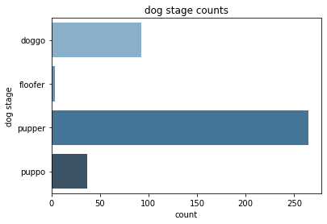

#### From the bar chart it can be conculed that As we can see the most common stage is pupper

### Percentage of different dog stage

A pie chart was drawn to represent the findings

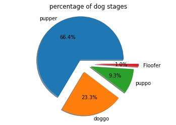

#### From the bar chart it can be conculed that As we can see the most common stage is pupper

1. Pupper ha sthe highest percentage
2. floofer ha sthe lowest percentage

   #### The relationship between retweet count and favorite count

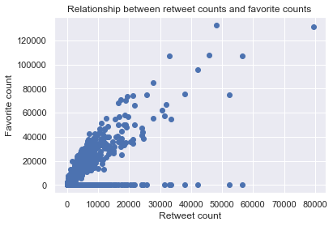

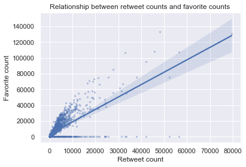

   #### from these scatter plot it could be conculded that there is a liner relation ship between count and favorite count

### The source of tweet count

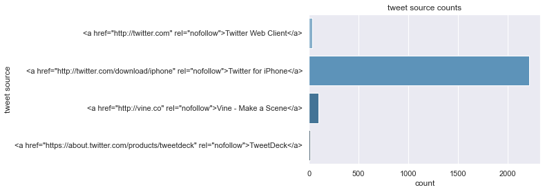

#### from these bar plot it could be conculded that the most tweet source is From Iphone